# Aquac

Camilo Vega

5 de julio de 2018

Cargando los paquetes nececesarios

```r
library(ggplot2)
library(dplyr)
library(tidyr)
```

Primero se organizaron los datos de tal forma que cada planta medida fuera una observacion, los tratamiento se nombraron con A para acuaponico y S para suelo, y se creo la varibale trat_rep como identificador de la repeticion de cada tratamiento, por ultimo las varibles Planta y rep se colocaron como variables categoricas.

Los datos quedaron entonces asi

```r
load("datos_tallos.RData")
datos_tallos
```

| Planta | trat_rep | trat | rep | Sem | n_tallos | long_tallo_p |
| --- | --- | --- | --- | --- | --- | --- |
| 1 | A1 | A | 1 | 1 | 2 | 2.9 |
| 2 | A1 | A | 1 | 1 | 1 | 3.1 |
| 3 | A1 | A | 1 | 1 | 2 | 3.4 |
| 4 | A1 | A | 1 | 1 | 2 | 3.0 |
| 5 | A1 | A | 1 | 1 | 1 | 3.1 |
| 6 | A1 | A | 1 | 1 | 2 | 3.8 |
| 1 | A2 | A | 2 | 1 | 2 | 2.5 |
| 2 | A2 | A | 2 | 1 | 2 | 3.0 |
| 3 | A2 | A | 2 | 1 | 1 | 3.4 |
| 4 | A2 | A | 2 | 1 | 2 | 2.8 |

[output cut: 206 more lines]

Ahora miramos los histogramas del numero de tallos y el largo de los tallos, por tratamiento para mirar posibles diferencias

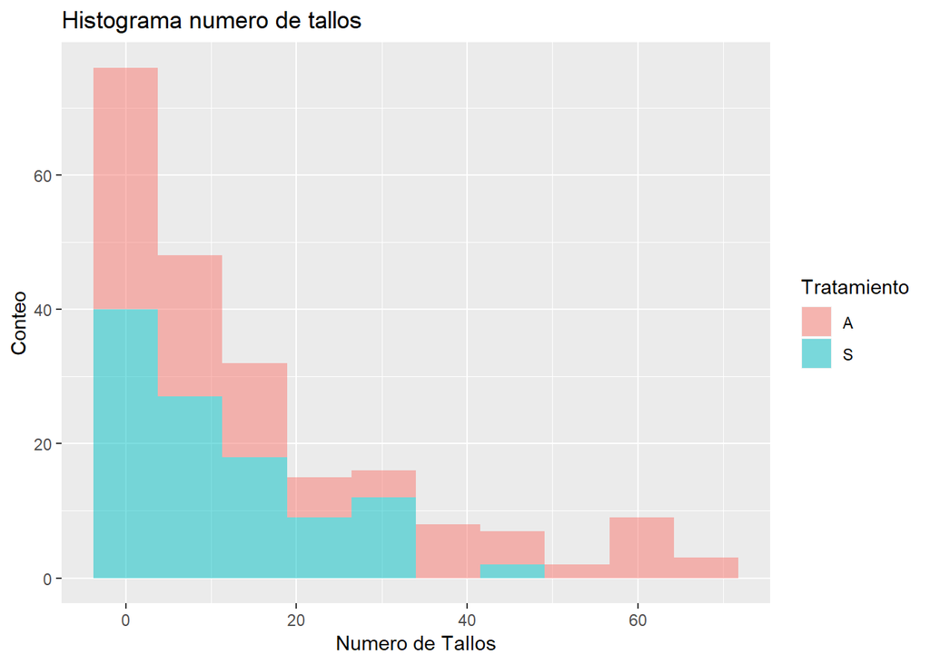

```r
ggplot(datos_tallos, aes(n_tallos, fill = trat)) +
  geom_histogram(bins = 10, alpha = 0.5) +
  labs(title = "Histograma numero de tallos", x = "Numero de Tallos", y = "Conteo", fill ="Tratamiento")
```

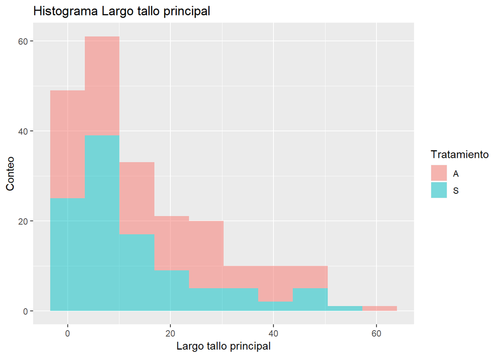

```r
ggplot(datos_tallos, aes(long_tallo_p, fill = trat)) +
  geom_histogram(bins = 10, alpha = 0.5) +
  labs(title = "Histograma Largo tallo principal", x = "Largo tallo principal", y = "Conteo", fill ="Tratamiento")
```

La distribucion de los datos se asemeja a una distribucion de Poisson, lo cual va en concordancia con conteo de datos, asi como con datos observados en el tiempo.

De igual forma se ve que tanto el numero de tallos como el largo del tallo principal muestran una diferencia para el tratamiento acuaponico respecto al de suelo.

Ahora miraremos la relacion del numero de tallos y largo del tallo principal en el tiempo deacuerdo al tratamiento

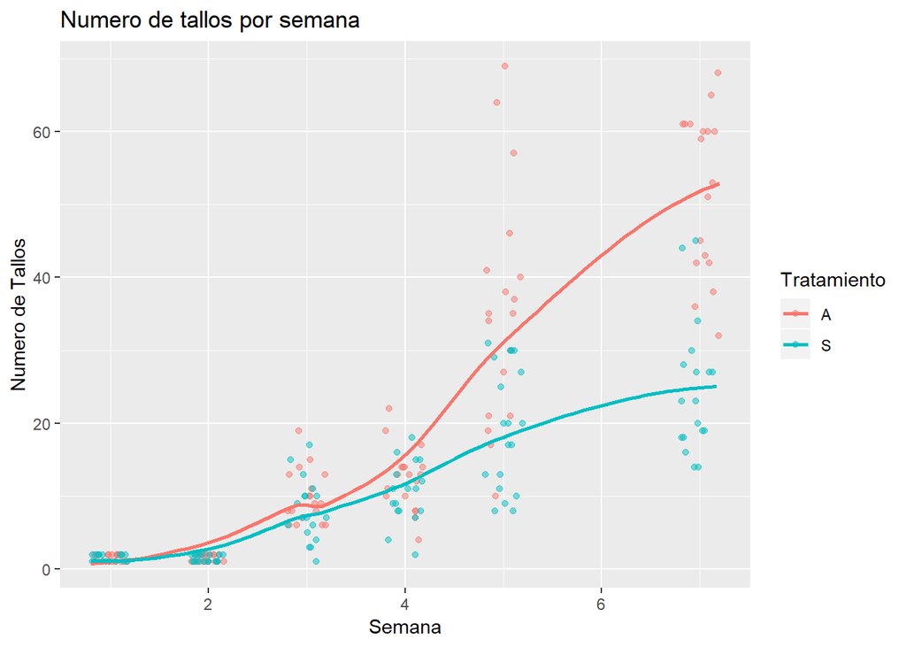

```r
ggplot(datos_tallos, aes(jitter(Sem), n_tallos, col = trat)) +
  geom_point(alpha = 0.5) +
  geom_smooth(se = F, method = "loess") +
  labs(title = "Numero de tallos por semana", x = "Semana", y = "Numero de Tallos", col = "Tratamiento")
```

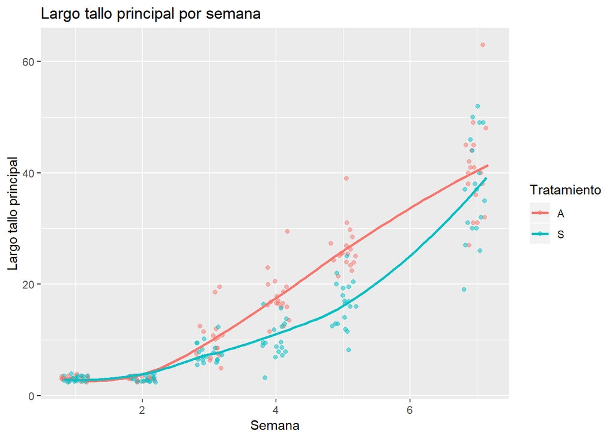

```r
ggplot(datos_tallos, aes(jitter(Sem), long_tallo_p, col = trat)) +
  geom_point(alpha = 0.5) +
  geom_smooth(se = F, method = "loess") +
  labs(title = "Largo tallo principal por semana", x = "Semana", y = "Largo tallo principal", col = "Tratamiento")
```

Vemos el comportamiento esperado en las graficas donde el numero de tallos y largo del tallo principal crecen exponencialmente en el tiempo.

Igualmete vemos para las dos graficas diferencias entre los resultados de los tratamientos

Ahora crearemos una tabla los promedios semanales por tratamiento

```r
datos_tallos %>%
      group_by(Sem,trat) %>%             #agrupamos por semana y tratmiento
      summarise(Promedio_tallos = mean(n_tallos), Promedio_largo_tallo_principal = mean(long_tallo_p))
```

| Sem | trat | Promedio_tallos | Promedio_largo_tallo_principal |
| --- | --- | --- | --- |
| 1 | A | 1.500000 | 3.055556 |
| 1 | S | 1.444444 | 2.994444 |
| 2 | A | 1.500000 | 3.055556 |
| 2 | S | 1.444444 | 2.994444 |
| 3 | A | 9.888889 | 9.988889 |
| 3 | S | 8.000000 | 7.655556 |
| 4 | A | 12.388889 | 17.655556 |
| 4 | S | 10.411765 | 10.052941 |
| 5 | A | 35.611111 | 26.372222 |
| 5 | S | 19.368421 | 16.342105 |

[output cut: 2 more lines]

Como se ve en la tabla el promedio semana de la cantidad de tallos y el largo del tallo principal es mas alto para los tratamientos acuaponicos respecto a los de suelo

Como vemos de la estadistica decriptiva los tallos cultivados en el sistema acuaponico presentan caracteristicas diferentes a los cultivados en suelo, asi que acontunuacion aplicaremos metodos estadisticos para determinar si estas diferencias son significativas

primero miraremos el numero de tallos:

Como se vio en la grafica de Numero de tallos por semana el numero de tallos crece exponencialmente a lo largo del tiempo razon por la cual transformalremos los datos de numero de tallos aplicandole raiz cuadrada con el fin de su relacion con la semana se asemeje mas a una linea.

luego crearemos un modelo lineal de la raiz del numero de tallos en funcion de la semana, el tratamiento y la relacion entre semana-tratamiento

```r
raiz_n_tallos = sqrt(datos_tallos$n_tallos) #transformacion de datos

modelo_n_tallos = lm(raiz_n_tallos~Sem*trat, data = datos_tallos) #creacion del modelo

summary(modelo_n_tallos) #resumen del modelo
```

```
##
## Call:
## lm(formula = raiz_n_tallos ~ Sem * trat, data = datos_tallos)
##
## Residuals:
##     Min      1Q  Median      3Q     Max
## -2.0264 -0.5441 -0.0572  0.5012  3.1860
##
## Coefficients:
##             Estimate Std. Error t value Pr(>|t|)
## (Intercept) -0.35044    0.16903  -2.073  0.03936 *
## Sem          1.09422    0.04060  26.951  < 2e-16 ***
## tratS        0.71271    0.23910   2.981  0.00321 **
## Sem:tratS   -0.39934    0.05736  -6.962 4.14e-11 ***
## ---
## Signif. codes:  0 '***' 0.001 '**' 0.01 '*' 0.05 '.' 0.1 ' ' 1
##
## Residual standard error: 0.832 on 212 degrees of freedom
## Multiple R-squared:  0.8338, Adjusted R-squared:  0.8315
## F-statistic: 354.6 on 3 and 212 DF,  p-value: < 2.2e-16
```

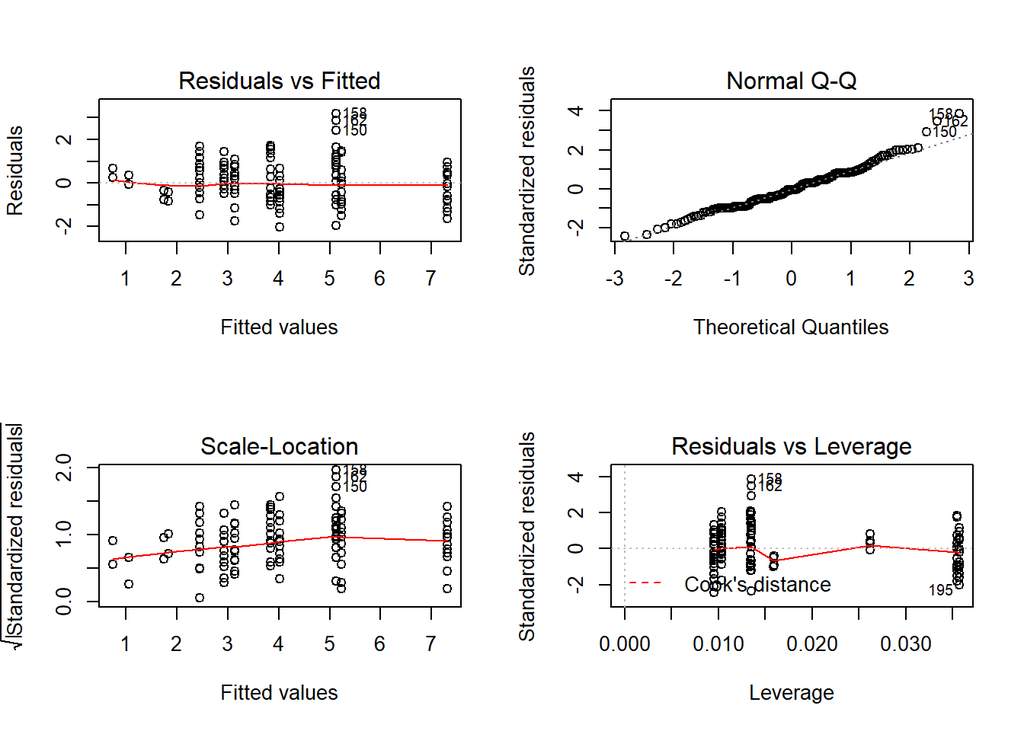

```r
par(mfrow = c(2,2))
plot(modelo_n_tallos)
```

Todos se ve vien a esepcion de uno 3 valoes extremos, en las filas 150,158 y 162, pero en general se ve que el modelo se acomoda a los supuestos de la regresion

ahora miraremos la anova para ver la significancia de las variables respecto a la raiz del numero de tallos

```r
anova(modelo_n_tallos)
```

|  | Df | Sum Sq | Mean Sq | F value | Pr(>F) |
| --- | --- | --- | --- | --- | --- |
| Sem | 1 | 672.24393 | 672.2439271 | 971.02072 | 4.316304e-81 |
| trat | 1 | 30.64833 | 30.6483278 | 44.26988 | 2.398731e-10 |
| Sem:trat | 1 | 33.55472 | 33.5547200 | 48.46801 | 4.135970e-11 |
| Residuals | 212 | 146.76897 | 0.6923065 | NA | NA |

Como se ve hay una diferencia SIGNIFICATIVA en la raiz del numero de tallos por semana, por tratamiento y en la relacion entre semana y tratamiento.

Ahora miraremos el modelo graficamente para saber en que consisten estas diferencias significativas

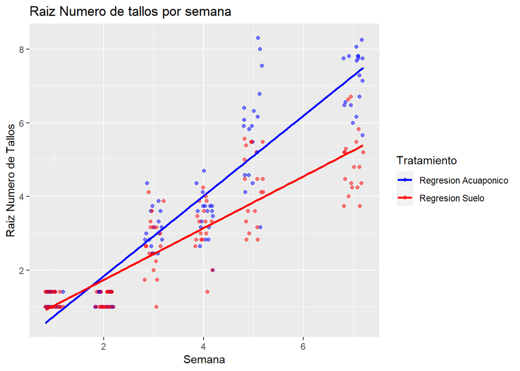

```r
ggplot(datos_tallos, aes(jitter(Sem), raiz_n_tallos, col = trat)) +
  geom_point(alpha = 0.5) +
  geom_smooth(se = F, method = "lm") +
  labs(title = "Raiz Numero de tallos por semana", x = "Semana", y = "Raiz Numero de Tallos", col = "Tratamiento") +
  scale_color_manual(labels = c("Regresion Acuaponico", "Regresion Suelo"), values = c("blue", "red"))
```

Como se ve a medida que pasa el tiempo la raiz de la cantidad de tallos aumenta en mayor proporcion (mayor pendiente) en el tratamiento Acuaponico respecto al tratamiento en suelo

ahora veamos en la tabla esta diferencia

```r
Diferencia_cantidad_tallos <- datos_tallos %>%
      group_by(Sem,trat) %>%             #agrupamos por semana y tratmiento
      summarise(Promedio_tallos = mean(n_tallos)) %>%
      spread(trat,Promedio_tallos) %>%
      summarise(Diferencia_promedio_numero_tallos_acua_suelo = A - S)
Diferencia_cantidad_tallos
```

| Sem | Diferencia_promedio_numero_tallos_acua_suelo |
| --- | --- |
| 1 | 0.05555556 |
| 2 | 0.05555556 |
| 3 | 1.88888889 |
| 4 | 1.97712418 |
| 5 | 16.24269006 |
| 7 | 27.27777778 |

ahora miremos esta diferencia graficamente

[figure not shown]

```r
ggplot(datos_tallos, aes(as.factor(Sem), n_tallos, fill = trat)) +
  geom_bar(stat="identity", position = "dodge") +
  labs(title = "Largo tallo principal \n (Acuaponico - Suelo)", x = "Semana", y = "Largo promedio tallo principal")+
   scale_fill_manual(name ="Tratamiento",labels = c("Acuaponico", "Suelo"), values = c("lightseagreen", "lightgoldenrod4"))
```

## Se ve entonces que a medida que va pasando el tiempo la diferencia promedio entre numero de tallos de acuaponicos respecto a suelo va aumentando

Ahora repetiremos el proceso con el largo de tallo principal:

Al igul que el numero de tallos el largo de tallo principal crece exponencialmente a lo largo del tiempo razon por la cual transformalremos los datos aplicando raiz cuadrada con el fin de su relacion con la semana se asemeje mas a una linea.

luego crearemos un modelo lineal de la raiz del largo del tallo principal en funcion de la semana, el tratamiento y la relacion entre semana-tratamiento

```r
raiz_long_tallo_p = sqrt(datos_tallos$long_tallo_p) #transformacion de datos

modelo_long_tallo_p = lm(sqrt(long_tallo_p)~Sem*trat, data = datos_tallos) #creacion del modelo

summary(modelo_long_tallo_p) #resumen del modelo
```

```
##
## Call:
## lm(formula = sqrt(long_tallo_p) ~ Sem * trat, data = datos_tallos)
##
## Residuals:
##     Min      1Q  Median      3Q     Max
## -1.6922 -0.4045  0.0345  0.3243  1.5093
##
## Coefficients:
##             Estimate Std. Error t value Pr(>|t|)
## (Intercept)  0.60600    0.11009   5.505 1.06e-07 ***
## Sem          0.84570    0.02644  31.982  < 2e-16 ***
## tratS       -0.08585    0.15572  -0.551  0.58201
## Sem:tratS   -0.10546    0.03736  -2.823  0.00521 **
## ---
## Signif. codes:  0 '***' 0.001 '**' 0.01 '*' 0.05 '.' 0.1 ' ' 1
##
## Residual standard error: 0.5419 on 212 degrees of freedom
## Multiple R-squared:  0.8972, Adjusted R-squared:  0.8957
## F-statistic: 616.5 on 3 and 212 DF,  p-value: < 2.2e-16
```

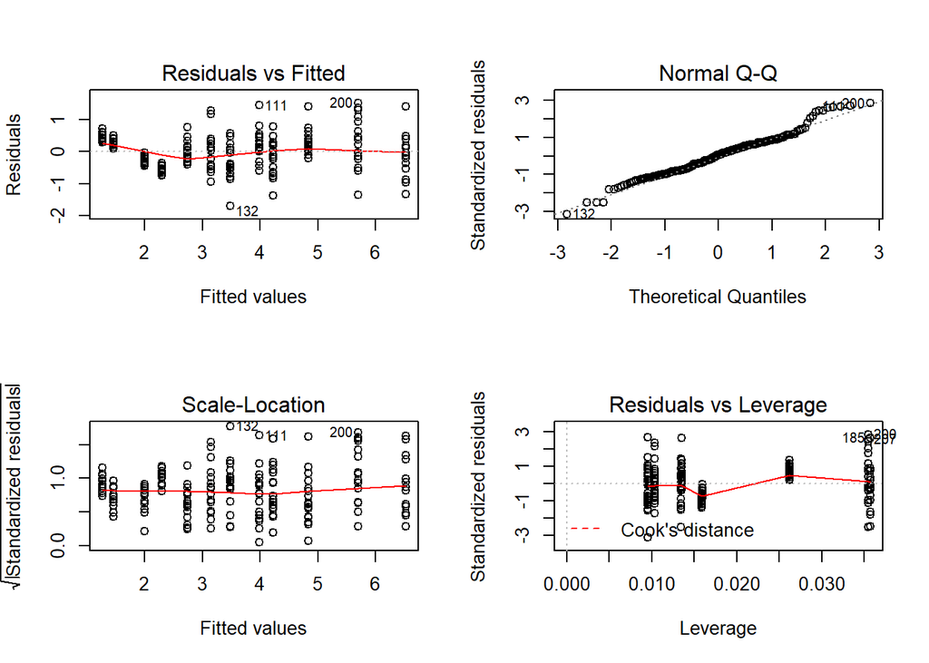

```r
par(mfrow = c(2,2))
plot(modelo_long_tallo_p)
```

El modelo no se ajusta muy bien al principio de normalidad de los residuales en especial en parte derecha de la grafica

intentaremos cambiando a una transformacion logaritmica

```r
log_long_tallo_p = log(datos_tallos$long_tallo_p) #transformacion de datos

modelo_long_tallo_p = lm(log_long_tallo_p~Sem*trat, data = datos_tallos) #creacion del modelo

summary(modelo_long_tallo_p) #resumen del modelo
```

```
##
## Call:
## lm(formula = log_long_tallo_p ~ Sem * trat, data = datos_tallos)
##
## Residuals:
##      Min       1Q   Median       3Q      Max
## -1.11482 -0.21111  0.01329  0.24868  0.91765
##
## Coefficients:
##             Estimate Std. Error t value Pr(>|t|)
## (Intercept)  0.60160    0.06639   9.062   <2e-16 ***
## Sem          0.48372    0.01595  30.335   <2e-16 ***
## tratS       -0.09690    0.09391  -1.032   0.3033
## Sem:tratS   -0.04040    0.02253  -1.793   0.0743 .
## ---
## Signif. codes:  0 '***' 0.001 '**' 0.01 '*' 0.05 '.' 0.1 ' ' 1
##
## Residual standard error: 0.3268 on 212 degrees of freedom
## Multiple R-squared:  0.8906, Adjusted R-squared:  0.889
## F-statistic: 575.2 on 3 and 212 DF,  p-value: < 2.2e-16
```

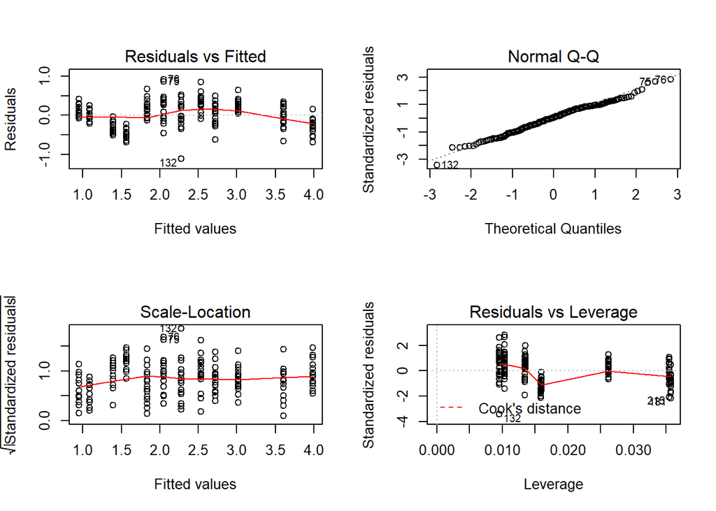

```r
par(mfrow = c(2,2))
plot(modelo_long_tallo_p)
```

Mejora con este modelo a pesar de tener algunos valores extremos en las observaciones 75,76 y 132

ahora miraremos la anova para ver la significancia de las variables respecto al logaritmo del largo del tallo principal

```r
anova(modelo_long_tallo_p)
```

|  | Df | Sum Sq | Mean Sq | F value | Pr(>F) |
| --- | --- | --- | --- | --- | --- |
| Sem | 1 | 180.6871814 | 180.6871814 | 1691.940113 | 5.152208e-103 |
| trat | 1 | 3.2473167 | 3.2473167 | 30.407610 | 1.012940e-07 |
| Sem:trat | 1 | 0.3434447 | 0.3434447 | 3.215988 | 7.434749e-02 |
| Residuals | 212 | 22.6400936 | 0.1067929 | NA | NA |

Vemos que hay una diferencia significativa en el logaritmo del largo del tallo principal respecto a la semana y el tratamiento, pero no la hay en la relacion semana-tratemiento.

miraremos si podemos sacar esta relacion semana-tratamiento del modelo

```r
modelo_long_tallo_p2 = lm(log_long_tallo_p~Sem+trat, data = datos_tallos)
anova(modelo_long_tallo_p, modelo_long_tallo_p2)
```

|  | Res.Df | RSS | Df | Sum of Sq | F | Pr(>F) |
| --- | --- | --- | --- | --- | --- | --- |
| 1 | 212 | 22.64009 | NA | NA | NA | NA |
| 2 | 213 | 22.98354 | -1 | -0.3434447 | 3.215988 | 0.07434749 |

Como vemos los modelos no son significativamente distintos por lo cual podemos sacar la relacion semana-tratamiento del modelo

Ahora evaluaremos el nuevo modelo y miraremos la anova del nuevo modelo para determinar si hay dieferencias significativas entre el logaritmo del largo del tallo principal en funcion de la semana y el tratamiento

```r
summary(modelo_long_tallo_p2) #resumen del modelo
```

```
##
## Call:
## lm(formula = log_long_tallo_p ~ Sem + trat, data = datos_tallos)
##
## Residuals:
##      Min       1Q   Median       3Q      Max
## -1.12136 -0.22300  0.01673  0.23838  0.90416
##
## Coefficients:
##             Estimate Std. Error t value Pr(>|t|)
## (Intercept)  0.67581    0.05218  12.952  < 2e-16 ***
## Sem          0.46348    0.01132  40.934  < 2e-16 ***
## tratS       -0.24523    0.04470  -5.486 1.16e-07 ***
## ---
## Signif. codes:  0 '***' 0.001 '**' 0.01 '*' 0.05 '.' 0.1 ' ' 1
##
## Residual standard error: 0.3285 on 213 degrees of freedom
## Multiple R-squared:  0.8889, Adjusted R-squared:  0.8879
## F-statistic: 852.3 on 2 and 213 DF,  p-value: < 2.2e-16
```

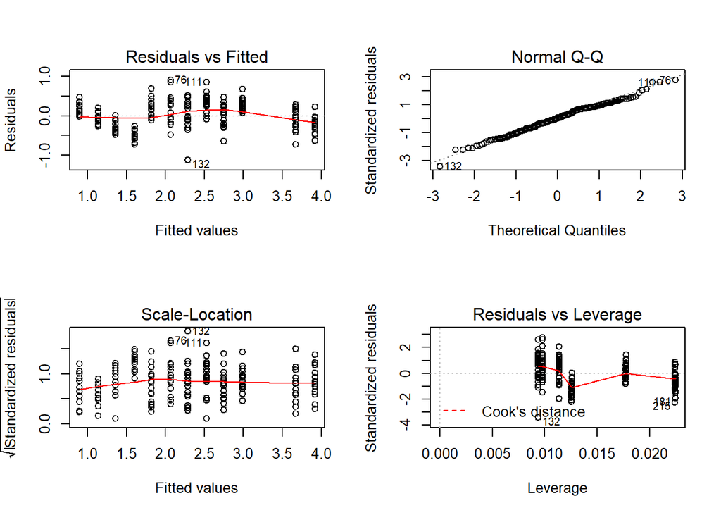

```r
par(mfrow = c(2,2))
plot(modelo_long_tallo_p2)
```

```r
anova(modelo_long_tallo_p2)
```

|  | Df | Sum Sq | Mean Sq | F value | Pr(>F) |
| --- | --- | --- | --- | --- | --- |
| Sem | 1 | 180.687181 | 180.6871814 | 1674.51892 | 7.128324e-103 |
| trat | 1 | 3.247317 | 3.2473167 | 30.09452 | 1.161374e-07 |
| Residuals | 213 | 22.983538 | 0.1079039 | NA | NA |

El modelo sigue siendo valido, y seguimos viendo que hay diferencias SIGNIFICATIVAS entre el logaritmo del lago del tallo principal por semana y por tratamiento

a contunuacnion veremos graficamente en que consiten esas diferencias

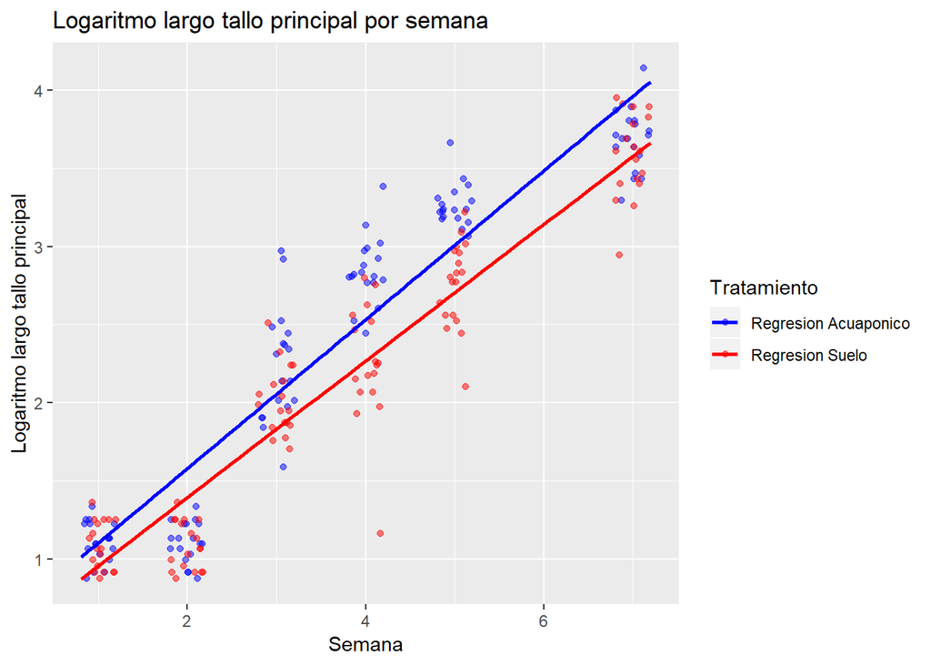

```r
ggplot(datos_tallos, aes(jitter(Sem), log_long_tallo_p, col = trat)) +
  geom_point(alpha = 0.5) +
  geom_smooth(se = F, method = "lm") +
  labs(title = "Logaritmo largo tallo principal por semana", x = "Semana", y = "Logaritmo largo tallo principal", col = "Tratamiento") +
  scale_color_manual(labels = c("Regresion Acuaponico", "Regresion Suelo"), values = c("blue", "red"))
```

Como se ve el logaritmo del largo del tallo principal es mayor en el tratamiento Acuaponico respecto al tratamiento en suelo sin embargo esta diferencia no varia mucho en el transcurso de las semanas (se mantiene casi paralela).

ahora veamos en la tabla esta diferencia

```r
Diferencia_largo_tallo_principal <- datos_tallos %>%
      group_by(Sem,trat) %>%             #agrupamos por semana y tratmiento
      summarise(Promedio_largo_tallo_p = mean(long_tallo_p)) %>%
      spread(trat,Promedio_largo_tallo_p) %>%
      summarise(Diferencia_promedio_largo_tallo_p_acua_suelo = A - S)
Diferencia_largo_tallo_principal
```

| Sem | Diferencia_promedio_largo_tallo_p_acua_suelo |
| --- | --- |
| 1 | 0.06111111 |
| 2 | 0.06111111 |
| 3 | 2.33333333 |
| 4 | 7.60261438 |
| 5 | 10.03011696 |
| 7 | 3.27777778 |

ahora veamolo graficamente

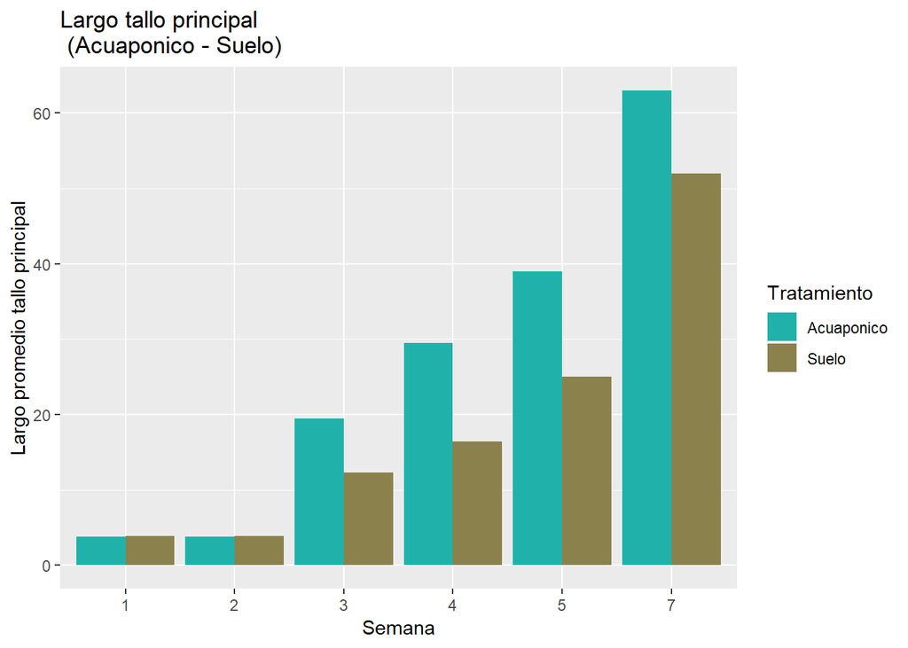

```r
ggplot(datos_tallos, aes(as.factor(Sem), long_tallo_p, fill = trat)) +
  geom_bar(stat="identity", position = "dodge") +
  labs(title = "Largo tallo principal \n (Acuaponico - Suelo)", x = "Semana", y = "Largo promedio tallo principal")+
   scale_fill_manual(name ="Tratamiento",labels = c("Acuaponico", "Suelo"), values = c("lightseagreen", "lightgoldenrod4"))
```

[figure not shown]

```r
ggplot(Diferencia_cantidad_tallos, aes(Sem, Diferencia_promedio_numero_tallos_acua_suelo)) +
  geom_line(col = "blue", lwd = 2) +
  labs(title = "Diferencia promedio entre numero de tallos \n (Acuaponico - Suelo)", x = "Semana", y = "Numero promedio de Tallos")
```

En conclusion vemo que el tratamiento de acuaponicos tiene una diferencia SIGNIFICATIVA respecto al atratamiento en suelo en lo referente al numero de tallos y largo del tallo principal.

En el tratamiento acuaponico el incremento por semana de la cantidad de tallos tiene una mayor proporcion que en el de suelo.

Asi mismo el tallo principal en el tratamiento acuaponico tiende a ser mas grande en las primeras semanas y luego se van acercando en tamalo con respecto al de suelo (**desde mi punto de vista esto puede tener una explicacion biologica ya que apesar de que cresta rapido en las primeras semanas en las ultimas se ve que no puede exeder el promedio de su especie)

[figure not shown]